# Data Acquisition

Using API to pull SP500 prices

Author

Mike Aguilar | https://www.linkedin.com/in/mike-aguilar-econ/

# Background

In one of the primary examples for this course we will be working with data on the SP500.

Our empirical goal here is to use an API to pull that data and clean so that it is ready for further analysis

# Data Acquisition

## Get tickers

Task: use tidyquant tq_index function to grab constituents of SP500

```r
sp500_members <- tq_index("SP500")
tickers <- sp500_members$symbol
```

## Set Date Range

Task: Set end date as 30Nov2025. Set start data as 10yrs prior

```r
end_date   <- as.Date("2025-11-30")
start_date <- end_date %m-% years(10)
```

## Get index prices

Task: use tq_get to pull the SP500 index monthly value using the adjusted closing price for the last trading day of each month

```r
spx_symbol <- "^GSPC"

spx_monthly <- tq_get(spx_symbol,
                      from = start_date,
                      to   = end_date,
                      get  = "stock.prices") %>%
  group_by(symbol) %>%
  tq_transmute(
    select      = adjusted,          # use adjusted close
    mutate_fun  = to.monthly,
    indexAt     = "lastof",
    col_rename  = "adj_close"
  )
```

## Get constituent prices

Task: Use tq_get to pull monthly adjusted closing price data for all the constituents.

Warning: This may take several minutes to run as it is pulling data for 500 stocks. Note also that this is not an institutional grade API, so there may be occasional timeouts or other issues such as some stocks not loading. Pro Tip: Load small subsets of tickers.

```r
sp500_monthly <- tq_get(tickers,
                        from = start_date,
                        to   = end_date,
                        get  = "stock.prices") %>%
  group_by(symbol) %>%
  tq_transmute(
    select      = adjusted,
    mutate_fun  = to.monthly,
    indexAt     = "lastof",
    col_rename  = "adj_close"
  ) %>%
  ungroup() %>%
  left_join(
    sp500_members %>% select(symbol, company),
    by = "symbol"
  ) %>%
  relocate(company, .after = symbol)
```

## Combine

Task: Combine the index and constituents into a single dataframe

```r
Price <- rbind(spx_monthly %>% select(date, symbol, adj_close),
      sp500_monthly %>% select(date, symbol, adj_close)) %>%
  select(date, symbol, adj_close) %>%
  pivot_wider(
    names_from  = symbol,
    values_from = adj_close
  )%>%
  rename("SP500" = "^GSPC","Date" = "date")
```

# Clean

## Gauge how dirty is the dataset

Task: Drop the date column and convert to long

```r
Price_long <- Price %>%
  pivot_longer(
    cols = -Date,
    names_to = "ticker",
    values_to = "adj_close"
  )
```

Task: Compute the fraction of missing observations for each ticker. Arrange from largest to smallest fraction missing

```r
missing_by_ticker <- Price_long %>%
  summarise(
    missing_frac = mean(is.na(adj_close)),
    .by = ticker
  ) %>%
  arrange(desc(missing_frac))
head(missing_by_ticker)
```

```
# A tibble: 6 × 2
  ticker missing_frac
  <chr>         <dbl>
1 Q             0.983
2 SNDK          0.917
3 GEV           0.826
4 SOLV          0.826
5 VLTO          0.785
6 KVUE          0.744
```

Task: Compute fraction of missing for each date

```r
missing_by_date <- Price_long %>%
  summarise(
    missing_frac = mean(is.na(adj_close)),
    .by = Date
  )
head(missing_by_date)
```

```
# A tibble: 6 × 2
  Date       missing_frac
  <date>            <dbl>
1 2015-11-30       0.0719
2 2015-12-31       0.0719
3 2016-01-31       0.0719
4 2016-02-29       0.0719
5 2016-03-31       0.0719
6 2016-04-30       0.0719
```

```r
tail(missing_by_date)
```

```
# A tibble: 6 × 2
  Date       missing_frac
  <date>            <dbl>
1 2025-06-30      0.00200
2 2025-07-31      0.00200
3 2025-08-31      0.00200
4 2025-09-30      0.00200
5 2025-10-31      0
6 2025-11-30      0
```

```r
entry_dates <- Price_long %>%
  filter(!is.na(adj_close)) %>%
  summarise(
    first_date = min(Date),
    .by = ticker
  ) %>%
  arrange(first_date)
head(entry_dates)
```

```
# A tibble: 6 × 2
  ticker first_date
  <chr>  <date>
1 SP500  2015-11-30
2 NVDA   2015-11-30
3 AAPL   2015-11-30
4 MSFT   2015-11-30
5 AMZN   2015-11-30
6 GOOGL  2015-11-30
```

```r
summary(entry_dates$first_date)
```

```
        Min.      1st Qu.       Median         Mean      3rd Qu.         Max.
"2015-11-30" "2015-11-30" "2015-11-30" "2016-03-19" "2015-11-30" "2025-10-31"
```

```r
entry_dates_sum <- entry_dates %>%
  mutate(year = lubridate::year(first_date)) %>%
  group_by(year) %>%
  summarise(n = n(), .groups = "drop") %>%
  arrange(desc(n))
```

Task: Plot the number of stocks without missing data in our panel over time.

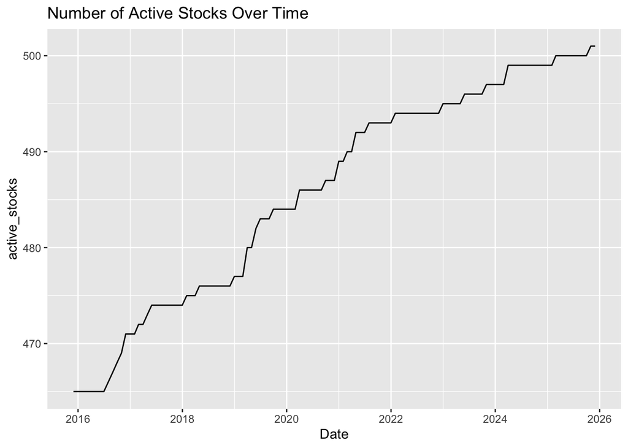

```r
Price_long %>%
  summarise(active_stocks = sum(!is.na(adj_close)), .by = Date) %>%
  ggplot(aes(Date, active_stocks)) +
  geom_line() +
  labs(title = "Number of Active Stocks Over Time")
```

## Clean the dataset

Find all tickers with entry date > start_date

```r
todrop<-entry_dates %>%
  filter(first_date > start_date) %>%
  select(ticker)
```

Task: Create a balanced panel by dropping any tickers that have not been trading for at least 10yrs. SP500_Mthly_Prices

```r
SP500_Mthly_Prices <-Price_long %>%
  filter(!ticker %in% todrop$ticker)
n_distinct(SP500_Mthly_Prices$ticker)
```

```
[1] 465
```

Task: Verify balance of the panel by computing the count of tickers on each date. Then compute the min and max of those counts.

```r
SP500_Mthly_Prices %>%
  dplyr::count(Date) %>%
  summarise(min = min(n), max = max(n))
```

```
# A tibble: 1 × 2
    min   max
  <int> <int>
1   465   465
```

# Engineering

Task: Construct a dataframe of simple 1mth returns. SP500-Monthly-SimpleReturns

```r
SP500_Mthly_SimpleReturns <- SP500_Mthly_Prices %>%
  arrange(ticker, Date) %>%
  group_by(ticker) %>%
  summarise(
    Date = Date[-1],
    OneMthSimpleRet = adj_close[-1] / adj_close[-length(adj_close)] - 1,
    .groups = "drop"
            )
```

Task: Construct a dataframe of log 1mth returns. SP500-Monthly-LogReturns

```r
SP500_Mthly_LogReturns <- SP500_Mthly_Prices %>%
  arrange(ticker, Date) %>%
  group_by(ticker) %>%
  summarise(
    Date = Date[-1],
    OneMthLogRet = log(adj_close[-1]) - log(adj_close[-length(adj_close)]),
    .groups = "drop"
            )
```

# Save

Task: Save SP500_Mthly_Prices, SP500_Mthly_SimpleReturns, and SP500_Mthly_LogReturns to a single R workspace using “save”

```r
save(
  SP500_Mthly_Prices,
  SP500_Mthly_SimpleReturns,
  SP500_Mthly_LogReturns,
  file = here("Data", "SP500_Monthly_Data.RData")
)
```

Task: Save the SP500_Mthly_Prices, SP500_Mthly_SimpleReturns, and SP500_Mthly_LogReturns to individual csv files

```r
readr::write_csv(SP500_Mthly_Prices,
                 here("Data", "SP500_Mthly_Prices.csv"))


readr::write_csv(SP500_Mthly_SimpleReturns,
                 here("Data", "SP500_Mthly_SimpleReturns.csv"))

readr::write_csv(SP500_Mthly_LogReturns,
                 here("Data", "SP500_Mthly_LogReturns.csv"))
```

## Verify saved

Task: Clear the environment

```r
cat("\014")  # clear console
```

```r
rm(list=ls())  # Clear the workspace
```

Task: Load the RData file

```r
load(here::here("Data", "SP500_Monthly_Data.RData"))
```